# Forecasting Singapore’s Daily USEP

AE6202 Group Project: data processing, models and evaluation

11 October 2026

**How to run.** The eight raw Excel files are in `data/` and are never modified. All exported tables and figures go to `output/`.

- `run_models: false` (default): sections 1, 2 and 5–8 run in a few minutes. The model forecasts of the full run (sections 3–4) are loaded from `output/model_runs.rds` and `output/model_forecasts.xlsx`.
- `run_models: true`: re-tunes and re-runs every model (several hours; needs `xgboost` and `keras3` with a TensorFlow backend) and overwrites those two files.

The saved full run used R 4.6.1, TensorFlow 2.21.0 and Keras 3.15.1.

```r
# TRUE only when knitting with params = list(run_models = TRUE)
run_models <- if (exists("params")) isTRUE(params$run_models) else FALSE

library(readxl)    # read the raw Excel files
library(writexl)   # export tables to Excel
library(fpp3)      # tsibble, feasts, ggplot2, dplyr, tidyr
library(forecast)  # ets(), Arima(), tslm(), checkresiduals(), dm.test(); loaded after fpp3 so forecast() is forecast::forecast
library(tseries)   # adf.test(), kpss.test()
library(knitr)     # kable()
if (run_models) {
  library(xgboost) # gradient-boosted trees
  library(keras3)  # LSTM; first-time setup: keras3::install_keras(backend = "tensorflow")
}

set.seed(2026)
data_dir   <- "data"
output_dir <- "output"
fig_dir    <- file.path(output_dir, "figures")
dir.create(fig_dir, recursive = TRUE, showWarnings = FALSE)

# Save a figure to output/figures and return it so it is also shown in the document
save_fig <- function(p, file, width = 8, height = 4) {
  png(file.path(fig_dir, file), width = width, height = height, units = "in", res = 300)
  print(p)
  dev.off()
  p
}
```

# 1 Data processing

## 1.1 Sample design

```r
start_date     <- as.Date("2021-01-01")  # first day of the study sample
end_date       <- as.Date("2026-08-31")  # last day with temperature data
train_end      <- as.Date("2024-12-31")  # training: 2021-2024
validation_end <- as.Date("2025-12-31")  # validation: 2025; test: 1 Jan - 31 Aug 2026
refit_days     <- 7L                     # model parameters are re-estimated every 7 days
```

## 1.2 Market data: half-hourly to daily

Each EMC file has 48 half-hourly trading periods per day. The daily value is the mean of the 48 periods. The code stops if a day has a duplicate, a missing value or fewer than 48 periods. Negative prices and spikes are kept.

```r
read_market <- function(file, value_column, variable) {
  raw <- as.data.frame(read_excel(file.path(data_dir, file), sheet = "Raw", .name_repair = "minimal"))
  # keep only the data columns; the source notes to the right are not variables
  raw <- data.frame(Date   = as.Date(raw[["DATE"]]),
                    Period = as.integer(raw[["PERIOD"]]),
                    Value  = as.numeric(raw[[value_column]]))
  raw <- raw[order(raw$Date, raw$Period), ]
  stopifnot(!anyDuplicated(raw[c("Date", "Period")]), all(raw$Period %in% 1:48), !anyNA(raw))
  daily <- raw |> group_by(Date) |> summarise(N = n(), Value = mean(Value), .groups = "drop")
  stopifnot(all(daily$N == 48L))  # complete days only
  daily$N <- NULL
  names(daily)[2] <- variable
  as.data.frame(daily)
}

usep        <- read_market("USEP.xlsx", "USEP ($/MWh)", "DailyUSEP")
demand      <- read_market("NEM_Demand_Forecast.xlsx", "DEMAND (MW)", "DemandMean")  # forecast demand, not actual
primary     <- read_market("Primary_Reserve_Price.xlsx", "PRICE ($/MWh)", "PrimaryReserve")
contingency <- read_market("Contingency_Reserve_Price.xlsx", "PRICE ($/MWh)", "ContingencyReserve")
regulation  <- read_market("Regulation_Price.xlsx", "PRICE ($/MWh)", "Regulation")
```

## 1.3 Fuel price: Brent in SGD

`BrentSGD` = Brent spot price (USD/barrel) × MAS SGD per USD. Both are trading-day series, so the latest available quote is carried forward over weekends and holidays; a future quote is never used.

```r
# Brent is stored newest-first in the source file
brent_raw <- read_excel(file.path(data_dir, "BrentUSD.xlsx"), sheet = "Raw", .name_repair = "minimal")
brent <- data.frame(Date = as.Date(brent_raw[[1]]), BrentUSD = as.numeric(brent_raw[[2]]))
brent <- brent[order(brent$Date), ]
stopifnot(!anyDuplicated(brent$Date), !anyNA(brent))

# MAS file: year and month appear only on the first row of each group, so fill them down;
# the notes at the bottom are dropped because they have no valid day or rate
fx_raw <- read_excel(file.path(data_dir, "USD_SGD.xlsx"), sheet = "Raw", col_types = "text", .name_repair = "minimal")
fx <- data.frame(Year = fx_raw[[1]], Month = fx_raw[[2]], Day = fx_raw[[3]], USD_SGD = fx_raw[[4]])
fx[fx == ""] <- NA_character_
fx <- fx |> fill(Year, Month, .direction = "down")
fx$Day     <- suppressWarnings(as.integer(fx$Day))
fx$USD_SGD <- suppressWarnings(as.numeric(fx$USD_SGD))
fx <- fx[!is.na(fx$Day) & !is.na(fx$USD_SGD), ]
fx$Month <- match(fx$Month, month.abb)
fx$Date  <- as.Date(sprintf("%s-%02d-%02d", fx$Year, fx$Month, fx$Day))
fx <- fx[order(fx$Date), c("Date", "USD_SGD")]
stopifnot(!anyDuplicated(fx$Date), !anyNA(fx))

# The calendar starts before 2021 so that 1-3 Jan 2021 use the 31 Dec 2020 rate
fuel <- data.frame(Date = seq(min(min(brent$Date), min(fx$Date)), end_date + 1L, by = "day"))
brent$BrentSourceDate <- brent$Date
fx$FXSourceDate       <- fx$Date
fuel <- fuel |>
  left_join(brent, by = "Date") |>
  left_join(fx, by = "Date") |>
  fill(BrentUSD, USD_SGD, BrentSourceDate, FXSourceDate, .direction = "down")
fuel$BrentSGD <- fuel$BrentUSD * fuel$USD_SGD
fuel <- fuel[fuel$Date >= start_date, ]
stopifnot(all(fuel$BrentSourceDate <= fuel$Date), all(fuel$FXSourceDate <= fuel$Date),
          all(fuel$USD_SGD[fuel$Date <= as.Date("2021-01-03")] == 1.3221))
```

## 1.4 Temperature

Five fixed MSS stations. The raw five-station mean is computed only when all five report; gaps are rebuilt below.

```r
stations <- c("Changi", "Jurong_West", "Ang_Mo_Kio", "Admiralty", "Sentosa_Island")
temp <- as.data.frame(read_excel(file.path(data_dir, "TempSG.xlsx"), sheet = "TempSG_Five_Stations", .name_repair = "minimal"))
temp <- temp[c("Date", stations)]
temp$Date <- as.Date(temp$Date)
temp$N_stations_available <- rowSums(!is.na(temp[stations]))
temp$TempSG_raw <- rowMeans(temp[stations], na.rm = FALSE)
stopifnot(!anyDuplicated(temp$Date), !anyNA(temp$Changi))  # Changi has no gaps
```

## 1.5 Calendar variables and the daily table

```r
# Public holidays incl. official in-lieu days and polling days; revised 2022 and 2023 dates.
# Sources: https://www.mom.gov.sg/employment-practices/public-holidays
# https://www.mom.gov.sg/newsroom/press-releases/2021/1021-revised-dates-for-hari-raya-puasa-and--hari-raya-haji-public-holidays-in-2022
# https://www.mom.gov.sg/newsroom/press-releases/2022/0929-revised-date-for-vesak-day-2023
holidays_2021 <- paste0("2021-", c("01-01", "02-12", "02-13", "04-02", "05-01", "05-13", "05-26", "07-20", "08-09", "11-04", "12-25"))
holidays_2022 <- paste0("2022-", c("01-01", "02-01", "02-02", "04-15", "05-01", "05-02", "05-03", "05-15", "05-16", "07-10", "07-11", "08-09", "10-24", "12-25", "12-26"))
holidays_2023 <- paste0("2023-", c("01-01", "01-02", "01-22", "01-23", "01-24", "04-07", "04-22", "05-01", "06-02", "06-29", "08-09", "09-01", "11-12", "11-13", "12-25"))
holidays_2024 <- paste0("2024-", c("01-01", "02-10", "02-11", "02-12", "03-29", "04-10", "05-01", "05-22", "06-17", "08-09", "10-31", "12-25"))
holidays_2025 <- paste0("2025-", c("01-01", "01-29", "01-30", "03-31", "04-18", "05-01", "05-03", "05-12", "06-07", "08-09", "10-20", "12-25"))
holidays_2026 <- paste0("2026-", c("01-01", "02-17", "02-18", "03-21", "04-03", "05-01", "05-27", "05-31", "06-01", "08-09", "08-10", "11-08", "11-09", "12-25"))
holiday_dates <- as.Date(c(holidays_2021, holidays_2022, holidays_2023, holidays_2024, holidays_2025, holidays_2026))

# One extra row (2026-09-01) is used only for the final next-day forecast; it is never scored
daily <- data.frame(Date = seq(start_date, end_date + 1L, by = "day"))
daily <- daily |>
  left_join(usep, by = "Date") |> left_join(demand, by = "Date") |>
  left_join(primary, by = "Date") |> left_join(contingency, by = "Date") |>
  left_join(regulation, by = "Date") |> left_join(fuel, by = "Date") |>
  left_join(temp, by = "Date")
daily$DayOfWeek     <- (as.POSIXlt(daily$Date)$wday + 6L) %% 7L  # 0 = Monday, ..., 6 = Sunday
daily$Weekend       <- as.integer(daily$DayOfWeek >= 5L)
daily$PublicHoliday <- as.integer(daily$Date %in% holiday_dates)
# Friday is the base day: Saturday = Weekend + Saturday, Sunday = Weekend (avoids a dummy trap)
daily$Monday    <- as.integer(daily$DayOfWeek == 0L)
daily$Tuesday   <- as.integer(daily$DayOfWeek == 1L)
daily$Wednesday <- as.integer(daily$DayOfWeek == 2L)
daily$Thursday  <- as.integer(daily$DayOfWeek == 3L)
daily$Saturday  <- as.integer(daily$DayOfWeek == 5L)
daily$TPCRegime <- as.integer(daily$Date >= as.Date("2023-07-01"))  # temporary price cap in force
daily$Sample <- ifelse(daily$Date <= train_end, "Train",
                ifelse(daily$Date <= validation_end, "Validation",
                ifelse(daily$Date <= end_date, "Test", "Forecast")))
stopifnot(all(diff(daily$Date) == 1L), !anyNA(daily$DailyUSEP[daily$Date <= end_date]))
```

## 1.6 Temperature gaps: ridge reconstruction

Changi is complete; the other four stations have gaps of up to 36 days. Each missing value is rebuilt from the station’s difference to Changi, predicted by a ridge regression on the other stations’ differences and month seasonality. Observed temperatures are never replaced. The penalty λ is chosen inside 2021–2024 only: fit up to three cut-offs, mask the next 7 or 36 days, and compare RMSE.

```r
# Inputs: other stations minus Changi, plus month sine/cosine; missing inputs -> training medians
ridge_inputs <- function(dat, target, medians = NULL) {
  others <- setdiff(stations, c("Changi", target))
  x <- as.matrix(dat[others]) - dat$Changi
  month <- as.integer(format(dat$Date, "%m"))
  x <- cbind(x, MonthSin = sin(2 * pi * month / 12), MonthCos = cos(2 * pi * month / 12))
  if (is.null(medians)) medians <- apply(x, 2, median, na.rm = TRUE)
  for (j in seq_len(ncol(x))) x[is.na(x[, j]), j] <- medians[j]
  list(x = x, medians = medians)
}

# Closed-form ridge on standardised inputs; the intercept is not penalised
fit_station <- function(dat, target, lambda) {
  observed <- dat[!is.na(dat[[target]]) & !is.na(dat$Changi), ]
  stopifnot(nrow(observed) >= 180L)
  input  <- ridge_inputs(observed, target)
  center <- colMeans(input$x)
  scale  <- apply(input$x, 2, sd)
  scale[scale == 0] <- 1
  x <- cbind(Intercept = 1, sweep(sweep(input$x, 2, center, "-"), 2, scale, "/"))
  y <- observed[[target]] - observed$Changi
  penalty <- diag(c(0, rep(lambda, ncol(x) - 1L)))
  coef <- solve(crossprod(x) + penalty, crossprod(x, y))
  list(target = target, medians = input$medians, center = center, scale = scale, coef = coef)
}

predict_station <- function(model, dat) {
  input <- ridge_inputs(dat, model$target, model$medians)
  x <- cbind(Intercept = 1, sweep(sweep(input$x, 2, model$center, "-"), 2, model$scale, "/"))
  as.numeric(x %*% model$coef) + dat$Changi
}

# Choose lambda per station by masked-block validation within the training period
temperature_cv <- data.frame()
temperature_lambda <- setNames(numeric(4L), stations[-1])
for (station in stations[-1]) {
  for (lambda in c(0.1, 1, 10)) {
    errors <- numeric()
    for (cutoff in as.Date(c("2021-12-31", "2022-12-31", "2023-12-31"))) {
      cutoff <- as.Date(cutoff, origin = "1970-01-01")
      model <- fit_station(temp[temp$Date <= cutoff, ], station, lambda)
      for (block in c(7L, 36L)) {
        validation <- temp[temp$Date > cutoff & temp$Date <= cutoff + block & !is.na(temp[[station]]), ]
        masked <- validation
        masked[[station]] <- NA_real_
        errors <- c(errors, predict_station(model, masked) - validation[[station]])
      }
    }
    temperature_cv <- rbind(temperature_cv, data.frame(Station = station, Lambda = lambda, N = length(errors),
                                                       MAE = mean(abs(errors)), RMSE = sqrt(mean(errors^2))))
  }
  candidate <- temperature_cv[temperature_cv$Station == station, ]
  temperature_lambda[station] <- candidate$Lambda[which.min(candidate$RMSE)]
}
temperature_lambda
```

```
##    Jurong_West     Ang_Mo_Kio      Admiralty Sentosa_Island
##            0.1            0.1           10.0           10.0
```

## 1.7 Model features

All inputs are known before the target day: price lags and 7-day moving statistics, and the previous day’s demand forecast, reserve and regulation prices, fuel price and temperature. Calendar dummies refer to the target day. `prepare_features()` is re-run at each weekly re-estimation so that temperature gaps are filled with models fitted on past data only.

```r
prepare_features <- function(cutoff, through = cutoff + refit_days) {
  dat <- daily[daily$Date <= through, ]
  # refit the station models on data up to the cut-off; fill missing cells only
  for (station in stations[-1]) {
    model <- fit_station(dat[dat$Date <= cutoff, ], station, temperature_lambda[station])
    missing <- which(is.na(dat[[station]]) & !is.na(dat$Changi))
    dat[missing, station] <- predict_station(model, dat[missing, ])
  }
  dat$TempSG_model <- rowMeans(dat[stations], na.rm = FALSE)
  dat$TempSG_reconstructed <- dat$N_stations_available < 5L
  # price history
  dat$USEP_lag1 <- lag(dat$DailyUSEP, 1L)
  dat$USEP_lag2 <- lag(dat$DailyUSEP, 2L)
  dat$USEP_lag7 <- lag(dat$DailyUSEP, 7L)
  dat$USEP_MA7 <- vapply(seq_len(nrow(dat)), function(i) if (i > 7L) mean(dat$DailyUSEP[(i - 7L):(i - 1L)]) else NA_real_, numeric(1))
  dat$USEP_SD7 <- vapply(seq_len(nrow(dat)), function(i) if (i > 7L) sd(dat$DailyUSEP[(i - 7L):(i - 1L)]) else NA_real_, numeric(1))
  # external variables, all lagged one day
  dat$DemandMean_lag1         <- lag(dat$DemandMean, 1L)
  dat$PrimaryReserve_lag1     <- lag(dat$PrimaryReserve, 1L)
  dat$PrimaryReserveLog_lag1  <- log1p(dat$PrimaryReserve_lag1)  # used only in the ancillary robustness check
  dat$ContingencyReserve_lag1 <- lag(dat$ContingencyReserve, 1L)
  dat$Regulation_lag1         <- lag(dat$Regulation, 1L)
  dat$BrentSGD_lag1           <- lag(dat$BrentSGD, 1L)
  dat$TempSG_model_lag1       <- lag(dat$TempSG_model, 1L)
  dat
}

price_features    <- c("USEP_lag1", "USEP_lag2", "USEP_lag7", "USEP_MA7", "USEP_SD7")
external_features <- c("DemandMean_lag1", "PrimaryReserve_lag1", "ContingencyReserve_lag1", "Regulation_lag1",
                       "BrentSGD_lag1", "TempSG_model_lag1", "Monday", "Tuesday", "Wednesday", "Thursday",
                       "Saturday", "Weekend", "PublicHoliday")
all_features <- c(price_features, external_features)
warmup_date  <- start_date + 28L  # 28-day warm-up shared by the feature-based models
initial_data <- prepare_features(train_end, train_end)
```

## 1.8 Descriptive statistics

```r
usep_sample <- daily[daily$Date <= end_date, ]
annual <- usep_sample |>
  group_by(Year = as.integer(format(Date, "%Y"))) |>
  summarise(N = n(), Mean = mean(DailyUSEP), SD = sd(DailyUSEP), Min = min(DailyUSEP),
            Median = median(DailyUSEP), P95 = quantile(DailyUSEP, 0.95), Max = max(DailyUSEP))
kable(annual, digits = 2, caption = "Table 3. Daily USEP by year (SGD/MWh)")
```

Table 3. Daily USEP by year (SGD/MWh)

| Year | N | Mean | SD | Min | Median | P95 | Max |
| --- | --- | --- | --- | --- | --- | --- | --- |
| 2021 | 365 | 196.33 | 264.08 | 58.61 | 106.44 | 602.44 | 2058.85 |
| 2022 | 365 | 291.81 | 133.29 | 112.19 | 256.38 | 545.91 | 1054.62 |
| 2023 | 365 | 247.52 | 181.96 | 101.58 | 186.32 | 625.24 | 1508.01 |
| 2024 | 366 | 163.18 | 106.38 | 69.49 | 129.29 | 393.12 | 693.49 |
| 2025 | 365 | 116.57 | 42.41 | 78.57 | 105.08 | 183.82 | 567.83 |
| 2026 | 243 | 197.10 | 81.21 | 82.60 | 180.36 | 358.93 | 698.63 |

```r
train_y  <- daily$DailyUSEP[daily$Date <= train_end]  # training series, 2021-2024
train_ts <- ts(train_y, frequency = 7)                # weekly seasonality
spike_threshold <- as.numeric(quantile(train_y, 0.95, type = 7))  # spike day: above the training 95th percentile

# Sample skewness (same definition as Excel SKEW)
skew <- function(x) {
  n <- length(x)
  n / ((n - 1) * (n - 2)) * sum(((x - mean(x)) / sd(x))^3)
}
round(c(MinPrice = min(usep_sample$DailyUSEP), SpikeThreshold = spike_threshold,
        Skew_level = skew(train_y), Skew_log = skew(log(train_y))), 2)
```

```
##       MinPrice SpikeThreshold     Skew_level       Skew_log
##          58.61         554.48           3.98           0.89
```

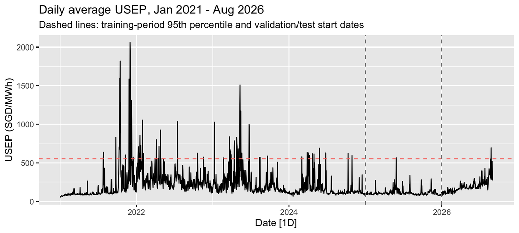

```r
usep_ts <- as_tsibble(usep_sample[c("Date", "DailyUSEP")], index = Date)
p1 <- usep_ts |>
  autoplot(DailyUSEP) +
  geom_hline(yintercept = spike_threshold, linetype = "dashed", colour = "#F8766D") +
  geom_vline(xintercept = as.Date(c("2025-01-01", "2026-01-01")), linetype = "dashed", colour = "grey50") +
  labs(title = "Daily average USEP, Jan 2021 - Aug 2026",
       subtitle = "Dashed lines: training-period 95th percentile and validation/test start dates",
       y = "USEP (SGD/MWh)")
save_fig(p1, "fig1_usep.png", 8, 3.6)
```

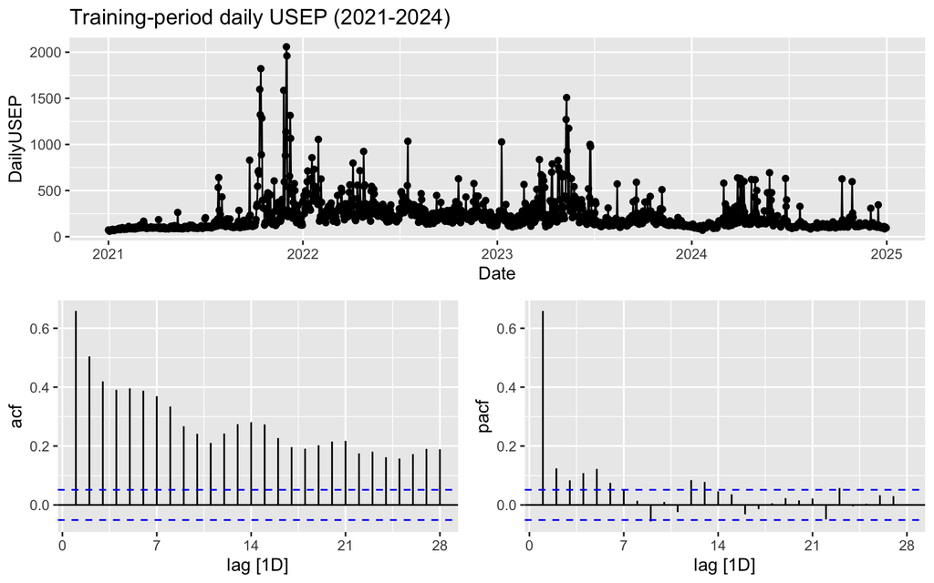

```r
p2 <- usep_ts |>
  filter(Date <= train_end) |>
  gg_tsdisplay(DailyUSEP, plot_type = "partial", lag_max = 28) +
  labs(title = "Training-period daily USEP (2021-2024)")
save_fig(p2, "fig2_acf_pacf.png", 8, 5)
```

## 1.9 Stationarity tests

ADF: H₀ = unit root. KPSS: H₀ = level-stationary. Using both tells us whether differencing is needed (`tseries` p-values are interpolated, so they are bounded at 0.01 and 0.10).

```r
unit_root <- function(x, series) {
  adf  <- adf.test(x)
  kpss <- kpss.test(x)
  data.frame(Series = series, ADF = unname(adf$statistic), ADF_p = adf$p.value,
             KPSS = unname(kpss$statistic), KPSS_p = kpss$p.value)
}
stationarity <- rbind(unit_root(train_ts, "Level"),
                      unit_root(log(train_ts), "Log"),
                      unit_root(diff(train_ts), "First difference"),
                      unit_root(diff(train_ts, lag = 7), "Seasonal difference (lag 7)"))
kable(stationarity, digits = 3, caption = "Table 5. Stationarity tests on training-period daily USEP")
```

Table 5. Stationarity tests on training-period daily USEP

| Series | ADF | ADF_p | KPSS | KPSS_p |
| --- | --- | --- | --- | --- |
| Level | -6.614 | 0.01 | 1.401 | 0.01 |
| Log | -4.872 | 0.01 | 2.151 | 0.01 |
| First difference | -16.681 | 0.01 | 0.006 | 0.10 |
| Seasonal difference (lag 7) | -12.102 | 0.01 | 0.013 | 0.10 |

# 2 Forecasting framework

Every model makes one-day-ahead forecasts on the same dates. Parameters are re-estimated every 7 days on an expanding window; within the week only the inputs (and the ETS/ARIMA states) are updated. Settings are chosen on 2025 (validation) and frozen before 2026 (test).

## 2.1 Evaluation metrics

```r
validation_dates <- daily$Date[daily$Sample == "Validation"]
test_dates       <- daily$Date[daily$Sample == "Test"]
# MASE scale: MAE of the seasonal naive (same weekday last week) over 2021-2024, fixed for all models
mase_scale <- mean(abs(train_y[8:length(train_y)] - train_y[1:(length(train_y) - 7L)]))

score <- function(actual, predicted) {
  error <- predicted - actual
  denominator <- abs(actual) + abs(predicted)
  smape <- ifelse(denominator == 0, 0, 200 * abs(error) / denominator)
  data.frame(N = length(error), RMSE = sqrt(mean(error^2)), MAE = mean(abs(error)),
             MASE = mean(abs(error)) / mase_scale, sMAPE = mean(smape))
}
```

## 2.2 Feature sets M0–M4

External variables are added in blocks: M0 price history → M1 + demand → M2 + reserve and regulation prices → M3 + fuel → M4 + temperature and calendar. M4 is the full model. Dynamic regression drops the explicit 1-, 2- and 7-day lags because its ARIMA errors model them.

```r
# Ancillary-price block of M2: the original three prices, or one of the four robustness variants
# (see "Ancillary-price robustness" under Model evaluation)
ancillary_features <- function(ancillary) switch(ancillary,
  original  = c("PrimaryReserve_lag1", "ContingencyReserve_lag1", "Regulation_lag1"),
  log_cont  = c("PrimaryReserveLog_lag1", "ContingencyReserve_lag1"),
  log_reg   = c("PrimaryReserveLog_lag1", "Regulation_lag1"),
  drop_cont = "ContingencyReserve_lag1",
  drop_reg  = "Regulation_lag1")

feature_names <- function(kind, step = 4L, tpc = FALSE, ancillary = "original") {
  features <- if (kind == "DynamicRegression") c("USEP_MA7", "USEP_SD7") else price_features
  if (step >= 1L) features <- c(features, "DemandMean_lag1")
  if (step >= 2L) features <- c(features, ancillary_features(ancillary))
  if (step >= 3L) features <- c(features, "BrentSGD_lag1")
  if (step >= 4L) features <- c(features, "TempSG_model_lag1", "Monday", "Tuesday", "Wednesday", "Thursday",
                                "Saturday", "Weekend", "PublicHoliday")
  if (tpc) features <- c(features, "TPCRegime")
  features
}
```

## 2.3 Model functions

Missing inputs are filled with medians of the current training window; the LSTM also standardises inputs and target with training-window means and SDs. XGBoost and LSTM choose the number of rounds/epochs by early stopping on the last 28 training days, then refit on the whole training window.

```r
fit_scaler <- function(x) {
  medians <- apply(x, 2, median, na.rm = TRUE)
  for (j in seq_len(ncol(x))) x[is.na(x[, j]), j] <- medians[j]
  center <- colMeans(x)
  scale  <- apply(x, 2, sd)
  scale[scale == 0] <- 1
  list(medians = medians, center = center, scale = scale)
}

transform_x <- function(x, scaler, standardize = FALSE) {
  for (j in seq_len(ncol(x))) x[is.na(x[, j]), j] <- scaler$medians[j]
  if (standardize) x <- sweep(sweep(x, 2, scaler$center, "-"), 2, scaler$scale, "/")
  x
}

# LSTM input: for each target row, the preceding `length` rows of features
make_sequences <- function(x, index, length) {
  sequences <- array(0, dim = c(length(index), length, ncol(x)))
  for (j in seq_along(index)) sequences[j, , ] <- x[(index[j] - length + 1L):index[j], , drop = FALSE]
  sequences
}

# One LSTM layer -> dropout -> linear output, trained on MSE with Adam
new_lstm <- function(config, n_features, seed) {
  clear_session()
  set_random_seed(seed)
  model <- keras_model_sequential(input_shape = c(config$sequence, n_features))
  model <- layer_lstm(model, units = config$units)
  model <- layer_dropout(model, rate = config$dropout)
  model <- layer_dense(model, units = 1L)
  compile(model, optimizer = optimizer_adam(learning_rate = config$learning_rate), loss = "mse")
  model
}

fit_xgb <- function(x, y, config, seed) {
  set.seed(seed)
  params <- c(list(objective = "reg:squarederror", eval_metric = "rmse", nthread = 1L, seed = seed), config)
  n <- nrow(x)
  inner   <- seq_len(n - 28L)
  holdout <- (n - 27L):n
  early <- xgb.train(params = params, data = xgb.DMatrix(x[inner, , drop = FALSE], label = y[inner]),
                     nrounds = 600L, evals = list(validation = xgb.DMatrix(x[holdout, , drop = FALSE], label = y[holdout])),
                     early_stopping_rounds = 20L, verbose = 0L)
  rounds <- which.min(as.numeric(attr(early, "evaluation_log")[[2]]))
  xgb.train(params = params, data = xgb.DMatrix(x, label = y), nrounds = rounds, verbose = 0L)
}

fit_lstm <- function(x, y, index, config, seed) {
  # 1) early stopping on the last 28 training days
  inner_index   <- head(index, -28L)
  holdout_index <- tail(index, 28L)
  inner_scaler <- fit_scaler(x[seq_len(max(inner_index)), , drop = FALSE])
  inner_x      <- transform_x(x, inner_scaler, TRUE)
  inner_y_mean <- mean(y[inner_index])
  inner_y_sd   <- sd(y[inner_index])
  early <- new_lstm(config, ncol(x), seed)
  history <- fit(early, make_sequences(inner_x, inner_index, config$sequence), (y[inner_index] - inner_y_mean) / inner_y_sd,
                 validation_data = list(make_sequences(inner_x, holdout_index, config$sequence), (y[holdout_index] - inner_y_mean) / inner_y_sd),
                 epochs = 100L, batch_size = 32L, shuffle = FALSE,
                 callbacks = list(callback_early_stopping(monitor = "val_loss", patience = 10L)), verbose = 0L)
  epochs <- which.min(history$metrics$val_loss)
  # 2) refit on the full training window with the chosen number of epochs
  scaler   <- fit_scaler(x[seq_len(max(index)), , drop = FALSE])
  scaled_x <- transform_x(x, scaler, TRUE)
  y_mean <- mean(y[index])
  y_sd   <- sd(y[index])
  model <- new_lstm(config, ncol(x), seed)
  fit(model, make_sequences(scaled_x, index, config$sequence), (y[index] - y_mean) / y_sd,
      epochs = epochs, batch_size = 32L, shuffle = FALSE, verbose = 0L)
  list(model = model, scaler = scaler, y_mean = y_mean, y_sd = y_sd)
}
```

## 2.4 Rolling one-day-ahead forecasts

`rolling_predict()` is the single forecasting engine used for validation, test, M0–M4 and the next-day forecast.

```r
rolling_predict <- function(kind, config, dates, step = 4L, tpc = FALSE, seed = 2026L, ancillary = "original") {
  prediction <- numeric(length(dates))
  features <- feature_names(kind, step, tpc, ancillary)
  for (j in seq_along(dates)) {
    date <- dates[j]
    # --- every 7th day: rebuild features with data up to yesterday and re-estimate ---
    if ((j - 1L) %% refit_days == 0L) {
      cutoff <- date - 1L
      dat <- prepare_features(cutoff, min(max(dates), cutoff + refit_days))
      train_index   <- which(dat$Date <= cutoff & dat$Date >= warmup_date)
      history_index <- which(dat$Date <= cutoff)
      y <- dat$DailyUSEP
      if (kind %in% c("TSLM", "DynamicRegression", "XGBoost", "LSTM")) {
        x <- as.matrix(dat[features])
        scaler  <- fit_scaler(x[train_index, , drop = FALSE])
        plain_x <- transform_x(x, scaler)
      }
      # ETS / SARIMA / dynamic regression keep the specification chosen by ets() / auto.arima() and re-estimate its parameters
      if (kind == "ETS") model <- ets(ts(y[history_index], frequency = 7), model = config$model, damped = config$damped)
      if (kind == "SARIMA") model <- Arima(ts(y[history_index], frequency = 7), order = config$order,
                                           seasonal = config$seasonal, include.constant = config$constant)
      if (kind == "TSLM") model <- tslm(reformulate(features, response = "DailyUSEP"),
                                        data = ts(data.frame(DailyUSEP = y[train_index], plain_x[train_index, , drop = FALSE]), frequency = 7))
      if (kind == "DynamicRegression") model <- Arima(ts(y[train_index], frequency = 7), xreg = plain_x[train_index, , drop = FALSE],
                                                      order = config$order, seasonal = config$seasonal,
                                                      include.constant = config$constant)
      if (kind == "XGBoost") model <- fit_xgb(plain_x[train_index, , drop = FALSE], y[train_index], config, seed)
      if (kind == "LSTM") {
        model <- fit_lstm(x, y, train_index, config, seed)
        message(paste("LSTM trained to", cutoff, "seed", seed))
      }
    }
    # --- every day: forecast today with the current parameters and all data up to yesterday ---
    current <- match(date, dat$Date)
    if (kind == "SeasonalNaive") prediction[j] <- as.numeric(snaive(ts(dat$DailyUSEP[seq_len(current - 1L)], frequency = 7), h = 1L)$mean)
    if (kind == "ETS") prediction[j] <- as.numeric(forecast(ets(ts(dat$DailyUSEP[seq_len(current - 1L)], frequency = 7),
                                                                model = model, use.initial.values = TRUE), h = 1L)$mean)
    if (kind == "SARIMA") prediction[j] <- as.numeric(forecast(Arima(ts(dat$DailyUSEP[seq_len(current - 1L)], frequency = 7),
                                                                     model = model), h = 1L)$mean)
    if (kind == "TSLM") prediction[j] <- as.numeric(forecast(model, newdata = as.data.frame(plain_x[current, , drop = FALSE]))$mean)
    if (kind == "DynamicRegression") {
      past <- which(dat$Date < date & dat$Date >= warmup_date)
      updated <- Arima(ts(dat$DailyUSEP[past], frequency = 7), xreg = plain_x[past, , drop = FALSE], model = model)
      prediction[j] <- as.numeric(forecast(updated, xreg = plain_x[current, , drop = FALSE], h = 1L)$mean)
    }
    if (kind == "XGBoost") prediction[j] <- as.numeric(predict(model, xgb.DMatrix(plain_x[current, , drop = FALSE])))
    if (kind == "LSTM") {
      scaled_x <- transform_x(x, model$scaler, TRUE)
      prediction[j] <- as.numeric(predict(model$model, make_sequences(scaled_x, current, config$sequence), verbose = 0L)) *
        model$y_sd + model$y_mean
    }
  }
  stopifnot(all(is.finite(prediction)))
  prediction
}
```

## 2.5 Candidate settings

ETS, SARIMA and dynamic regression follow the course workflow: `ets()` and `auto.arima()` choose the specification on the training period (AICc; `auto.arima()` picks d and D by unit-root tests), and that specification is frozen.

```r
# SARIMA: auto.arima() on 2021-2024; dynamic regression: auto.arima() with the feature set as xreg
arima_candidates <- function(kind, step = 4L, tpc = FALSE, ancillary = "original") {
  if (kind == "SARIMA") {
    fit <- auto.arima(train_ts)
  } else {
    train <- initial_data[initial_data$Date >= warmup_date, ]
    x <- as.matrix(train[feature_names(kind, step, tpc, ancillary)])
    fit <- auto.arima(ts(train$DailyUSEP, frequency = 7), xreg = transform_x(x, fit_scaler(x)))
  }
  # arma = (p, q, P, Q, period, d, D)
  list(list(order    = as.integer(fit$arma[c(1, 6, 2)]),
            seasonal = as.integer(fit$arma[c(3, 7, 4)]),
            constant = any(c("intercept", "drift") %in% names(coef(fit)))))
}

# ETS: ets() chooses error, trend and seasonal components by AICc on 2021-2024
ets_candidates <- function() {
  fit <- ets(train_ts)
  list(list(model = paste(fit$components[1:3], collapse = ""), damped = as.logical(fit$components[4])))
}

# XGBoost and LSTM: 12 random draws from each grid (seed fixed, order of sampling matters)
set.seed(2026)
xgb_grid <- expand.grid(max_depth = c(2L, 3L, 4L), eta = c(0.03, 0.1), min_child_weight = c(1, 5),
                        subsample = c(0.8, 1), colsample_bytree = c(0.8, 1), lambda = c(1, 5))
xgb_grid <- xgb_grid[sample(nrow(xgb_grid), 12L), ]
xgb_candidates <- lapply(seq_len(nrow(xgb_grid)), function(i) as.list(xgb_grid[i, ]))
lstm_grid <- expand.grid(sequence = c(7L, 14L, 28L), units = c(16L, 32L), dropout = c(0.1, 0.2), learning_rate = c(0.001, 0.0005))
lstm_grid <- lstm_grid[sample(nrow(lstm_grid), 12L), ]
lstm_candidates <- lapply(seq_len(nrow(lstm_grid)), function(i) as.list(lstm_grid[i, ]))

get_candidates <- function(kind, step = 4L, tpc = FALSE, ancillary = "original") {
  if (kind == "ETS") return(ets_candidates())
  if (kind %in% c("SARIMA", "DynamicRegression")) return(arima_candidates(kind, step, tpc, ancillary))
  if (kind == "TSLM") return(list(list()))
  if (kind == "XGBoost") return(xgb_candidates)
  if (kind == "LSTM") return(lstm_candidates)
}
```

# 3 Validation: tuning on 2025

*Runs only when `run_models = TRUE`.* Each candidate is forecast over the whole of 2025; the lowest validation RMSE wins (ETS, SARIMA and dynamic regression have a single candidate, chosen by `ets()` / `auto.arima()`). `TPCRegime` is kept only if it lowers the full-year RMSE by at least 1 % and improves at least three quarters. The LSTM’s final forecast averages three random seeds. The recommended model is the one with the lowest validation RMSE, preferring the simpler structure when within 1 % of the best.

```r
if (run_models) {
  validation_actual <- daily$DailyUSEP[match(validation_dates, daily$Date)]
  validation_log <- data.frame()
  tpc_log <- data.frame()

  # Forecast 2025 with every candidate; a failed candidate is logged, never silently skipped
  tune <- function(kind, candidates, step = 4L, tpc = FALSE) {
    predictions <- vector("list", length(candidates))
    rmse <- rep(Inf, length(candidates))
    for (i in seq_along(candidates)) {
      message(paste("Validation", kind, "M", step, "TPC", tpc, "candidate", i))
      started <- proc.time()[["elapsed"]]
      failure <- ""
      record_failure <- function(e) {
        failure <<- conditionMessage(e)
        NULL
      }
      predictions[i] <- list(tryCatch(rolling_predict(kind, candidates[[i]], validation_dates, step, tpc), error = record_failure))
      if (!is.null(predictions[[i]])) rmse[i] <- sqrt(mean((predictions[[i]] - validation_actual)^2))
      validation_log <<- rbind(validation_log, data.frame(Model = kind, Step = step, TPC = tpc, Candidate = i, RMSE = rmse[i],
                                                          Seconds = proc.time()[["elapsed"]] - started, Failure = failure))
    }
    stopifnot(any(is.finite(rmse)))
    best <- which.min(rmse)
    list(config = candidates[[best]], prediction = predictions[[best]], tpc = tpc, step = step, RMSE = rmse[best])
  }

  # Keep TPCRegime only if RMSE improves >= 1% over the year and in >= 3 quarters
  select_tpc <- function(kind) {
    without <- tune(kind, get_candidates(kind, 4L, FALSE), 4L, FALSE)
    with    <- tune(kind, get_candidates(kind, 4L, TRUE), 4L, TRUE)
    quarter <- (as.integer(format(validation_dates, "%m")) - 1L) %/% 3L + 1L
    quarter_gain <- vapply(1:4, function(q)
      sqrt(mean((without$prediction[quarter == q] - validation_actual[quarter == q])^2)) -
        sqrt(mean((with$prediction[quarter == q] - validation_actual[quarter == q])^2)), numeric(1))
    gain <- 1 - with$RMSE / without$RMSE
    keep <- gain >= 0.01 && sum(quarter_gain > 0) >= 3L
    tpc_log <<- rbind(tpc_log, data.frame(Model = kind, RelativeImprovement = gain, BetterQuarters = sum(quarter_gain > 0), KeepTPC = keep))
    if (keep) with else without
  }

  # Full models (M4)
  selected <- list()
  selected$ETS    <- tune("ETS", get_candidates("ETS"))
  selected$SARIMA <- tune("SARIMA", get_candidates("SARIMA"))
  for (kind in c("TSLM", "DynamicRegression", "XGBoost", "LSTM")) selected[[kind]] <- select_tpc(kind)

  # M0-M3 are tuned separately; each keeps the TPC choice of its full model
  incremental <- list()
  for (kind in c("DynamicRegression", "XGBoost")) {
    for (step in 0:4) {
      key <- paste0(kind, "_M", step)
      incremental[[key]] <- if (step == 4L) selected[[kind]] else
        tune(kind, get_candidates(kind, step, selected[[kind]]$tpc), step, selected[[kind]]$tpc)
    }
  }

  # LSTM: average of three seeds
  seeds <- c(2026L, 2027L, 2028L)
  selected$LSTM$prediction <- rowMeans(sapply(seeds, function(seed)
    rolling_predict("LSTM", selected$LSTM$config, validation_dates, 4L, selected$LSTM$tpc, seed)))

  # Recommendation rule, fixed before the test period
  validation_rmse <- vapply(selected, function(x) sqrt(mean((x$prediction - validation_actual)^2)), numeric(1))
  simplicity <- c("ETS", "SARIMA", "TSLM", "DynamicRegression", "XGBoost", "LSTM")
  eligible <- names(validation_rmse)[validation_rmse <= min(validation_rmse) * 1.01]
  recommended <- simplicity[simplicity %in% eligible][1]

  freeze <- list(models = selected, incremental = incremental, recommended = recommended,
                 temperature_lambda = temperature_lambda, spike_threshold = spike_threshold, mase_scale = mase_scale,
                 refit_days = refit_days, interval_window = 180L, interval_min = 100L, seeds = seeds)

  validation_predictions <- data.frame(Date = validation_dates, Actual = validation_actual)
  validation_predictions$SeasonalNaive <- rolling_predict("SeasonalNaive", list(), validation_dates)
  for (kind in names(selected)) validation_predictions[[kind]] <- selected[[kind]]$prediction

  # checkpoint: settings are frozen before any test forecast is made
  saveRDS(list(freeze = freeze, selected = selected, validation = validation_predictions), file.path(output_dir, "model_runs.rds"))
}
```

# 4 Test forecasts: January–August 2026

*Runs only when `run_models = TRUE`.* The frozen settings are applied to 2026 with the same weekly re-estimation; nothing is re-tuned on test results.

```r
if (run_models) {
  test_prediction <- data.frame(Date = test_dates, Actual = daily$DailyUSEP[match(test_dates, daily$Date)])
  test_prediction$SeasonalNaive <- rolling_predict("SeasonalNaive", list(), test_dates)
  for (kind in names(selected)) {
    config <- selected[[kind]]
    test_prediction[[kind]] <- if (kind == "LSTM") {
      rowMeans(sapply(seeds, function(seed) rolling_predict(kind, config$config, test_dates, 4L, config$tpc, seed)))
    } else {
      rolling_predict(kind, config$config, test_dates, 4L, config$tpc)
    }
  }

  # M0-M4 test forecasts (M4 = the full model already forecast above)
  incremental_prediction <- data.frame(Date = test_dates, Actual = test_prediction$Actual)
  for (key in names(incremental)) {
    kind   <- sub("_M[0-4]$", "", key)
    config <- incremental[[key]]
    incremental_prediction[[key]] <- if (config$step == 4L) test_prediction[[kind]] else
      rolling_predict(kind, config$config, test_dates, config$step, config$tpc)
  }

  # Forecast for 2026-09-01, the day after the data end
  interval_models <- c("SeasonalNaive", names(selected))
  next_prediction <- data.frame(Date = end_date + 1L, Model = interval_models, Prediction = NA_real_)
  for (kind in interval_models) {
    config <- selected[[kind]]
    value <- if (kind == "SeasonalNaive") {
      rolling_predict(kind, list(), end_date + 1L)
    } else if (kind == "LSTM") {
      mean(vapply(seeds, function(seed) rolling_predict(kind, config$config, end_date + 1L, 4L, config$tpc, seed), numeric(1)))
    } else {
      rolling_predict(kind, config$config, end_date + 1L, 4L, config$tpc)
    }
    next_prediction$Prediction[next_prediction$Model == kind] <- value
  }

  saveRDS(list(freeze = freeze, selected = selected, validation = validation_predictions, test = test_prediction),
          file.path(output_dir, "model_runs.rds"))
  write_xlsx(list(Validation = validation_predictions, Test = test_prediction, Incremental = incremental_prediction,
                  NextDay = next_prediction, ValidationLog = validation_log, TPC = tpc_log),
             file.path(output_dir, "model_forecasts.xlsx"))
}
```

## 4.1 Load the saved model run

With `run_models = FALSE` the forecasts of the full run are read back here; everything below uses the same objects in both modes.

```r
if (!run_models) {
  runs <- readRDS(file.path(output_dir, "model_runs.rds"))
  freeze   <- runs$freeze
  selected <- runs$selected
  validation_predictions <- runs$validation
  test_prediction        <- runs$test
  read_sheet <- function(sheet) {
    x <- as.data.frame(read_excel(file.path(output_dir, "model_forecasts.xlsx"), sheet = sheet))
    if ("Date" %in% names(x)) x$Date <- as.Date(x$Date)
    x
  }
  incremental_prediction <- read_sheet("Incremental")
  next_prediction        <- read_sheet("NextDay")
  validation_log         <- read_sheet("ValidationLog")
  tpc_log                <- read_sheet("TPC")
}
incremental <- freeze$incremental
recommended <- freeze$recommended

# Frozen settings of the six models
setting_text <- function(cfg) if (length(cfg) == 0) "OLS" else
  paste(names(cfg), vapply(cfg, function(v) paste(v, collapse = ","), character(1)), sep = " = ", collapse = "; ")
frozen_table <- data.frame(Model = names(selected),
                           Setting = vapply(selected, function(s) setting_text(s$config), character(1)),
                           TPC = vapply(selected, function(s) s$tpc, logical(1)))
kable(frozen_table, row.names = FALSE, caption = "Frozen settings chosen on the 2025 validation period")
```

Frozen settings chosen on the 2025 validation period

| Model | Setting | TPC |
| --- | --- | --- |
| ETS | model = MAM; damped = FALSE | FALSE |
| SARIMA | order = 2,1,2; seasonal = 0,0,2; constant = FALSE | FALSE |
| TSLM | OLS | FALSE |
| DynamicRegression | order = 1,0,0; seasonal = 0,0,0; constant = TRUE | TRUE |
| XGBoost | max_depth = 4; eta = 0.1; min_child_weight = 5; subsample = 1; colsample_bytree = 1; lambda = 1 | FALSE |
| LSTM | sequence = 28; units = 16; dropout = 0.1; learning_rate = 0.001 | FALSE |

# 5 Model evaluation

The yesterday’s-price benchmark (Naive) is added to the validation and test forecasts, so every comparison includes two benchmarks: Naive and SeasonalNaive.

```r
yesterday <- function(dates) daily$DailyUSEP[match(dates - 1L, daily$Date)]
val  <- validation_predictions
test <- test_prediction
val$Naive  <- yesterday(val$Date)
test$Naive <- yesterday(test$Date)
eval_models <- c("Naive", "SeasonalNaive", "ETS", "SARIMA", "TSLM", "DynamicRegression", "XGBoost", "LSTM")
rmse <- function(df, m) sqrt(mean((df$Actual - df[[m]])^2))
```

## 5.1 Forecast accuracy

```r
accuracy_table <- bind_rows(lapply(eval_models, function(m)
  cbind(Model = m, Val_RMSE = rmse(val, m), score(test$Actual, test[[m]]))))
base_mae  <- function(m) accuracy_table$MAE[accuracy_table$Model == m]
base_rmse <- function(m) accuracy_table$RMSE[accuracy_table$Model == m]
accuracy_table <- accuracy_table |>
  mutate(MAE_vs_SNaive = MAE / base_mae("SeasonalNaive"),
         MAE_vs_Naive  = MAE / base_mae("Naive"),
         RMSE_gain_vs_SNaive = 1 - RMSE / base_rmse("SeasonalNaive"),
         RMSE_gain_vs_Naive  = 1 - RMSE / base_rmse("Naive")) |>
  arrange(RMSE)
kable(accuracy_table, digits = 3, row.names = FALSE,
      caption = "Table 7. Validation RMSE and test-period accuracy (RMSE, MAE, MASE, sMAPE are test values), sorted by test RMSE")
```

Table 7. Validation RMSE and test-period accuracy (RMSE, MAE, MASE, sMAPE are test values), sorted by test RMSE

| Model | Val_RMSE | N | RMSE | MAE | MASE | sMAPE | MAE_vs_SNaive | MAE_vs_Naive | RMSE_gain_vs_SNaive | RMSE_gain_vs_Naive |
| --- | --- | --- | --- | --- | --- | --- | --- | --- | --- | --- |
| SARIMA | 36.157 | 243 | 50.214 | 28.190 | 0.281 | 12.804 | 0.736 | 0.887 | 0.229 | 0.152 |
| LSTM | 35.924 | 243 | 50.395 | 30.085 | 0.300 | 14.153 | 0.786 | 0.947 | 0.226 | 0.149 |
| XGBoost | 35.233 | 243 | 53.018 | 31.239 | 0.311 | 14.230 | 0.816 | 0.983 | 0.185 | 0.104 |
| DynamicRegression | 41.617 | 243 | 56.970 | 37.396 | 0.373 | 19.783 | 0.976 | 1.177 | 0.125 | 0.038 |
| ETS | 40.435 | 243 | 58.714 | 34.877 | 0.348 | 15.112 | 0.911 | 1.098 | 0.098 | 0.008 |
| Naive | 41.911 | 243 | 59.194 | 31.764 | 0.317 | 13.828 | 0.829 | 1.000 | 0.091 | 0.000 |
| TSLM | 42.626 | 243 | 63.362 | 42.151 | 0.420 | 23.928 | 1.101 | 1.327 | 0.027 | -0.070 |
| SeasonalNaive | 51.050 | 243 | 65.092 | 38.296 | 0.382 | 17.257 | 1.000 | 1.206 | 0.000 | -0.100 |

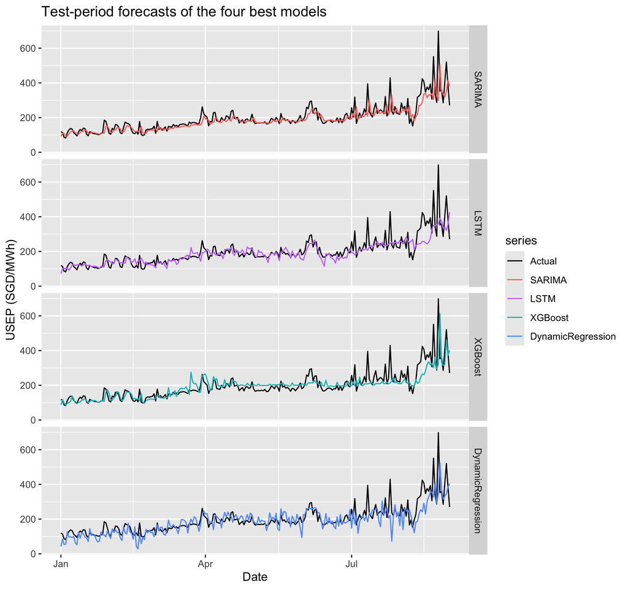

```r
model_colours <- c(Naive = "#7F7F7F", SARIMA = "#F8766D", ETS = "#7CAE00", TSLM = "#E76BF3",
                   DynamicRegression = "#619CFF", XGBoost = "#00BFC4", LSTM = "#C77CFF")
# The four best models by test RMSE, benchmarks excluded
top4 <- head(setdiff(accuracy_table$Model, c("Naive", "SeasonalNaive")), 4)
p3 <- test |>
  select(Date, Actual, all_of(top4)) |>
  pivot_longer(all_of(top4), names_to = "Model", values_to = "Forecast") |>
  mutate(Model = factor(Model, levels = top4)) |>
  ggplot(aes(x = Date)) +
  geom_line(aes(y = Actual, colour = "Actual")) +
  geom_line(aes(y = Forecast, colour = Model)) +
  facet_grid(vars(Model)) +
  scale_colour_manual(values = c(Actual = "black", model_colours[top4]), breaks = c("Actual", top4)) +
  labs(title = "Test-period forecasts of the four best models", y = "USEP (SGD/MWh)", colour = "series")
save_fig(p3, "fig3_top4.png", 8, 7.5)
```

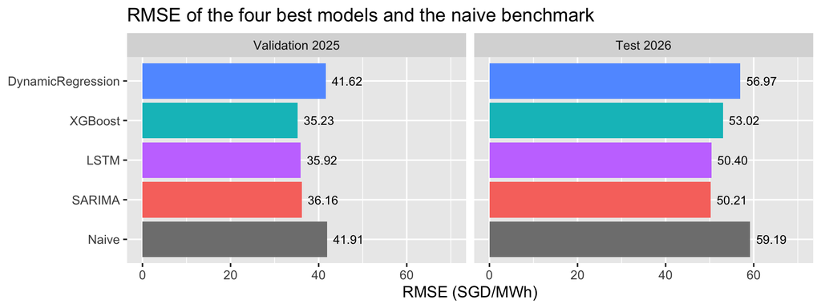

```r
bar_models <- c("Naive", top4)
p4 <- tibble(Model  = factor(rep(bar_models, 2), levels = bar_models),
             Sample = factor(rep(c("Validation 2025", "Test 2026"), each = length(bar_models)),
                             levels = c("Validation 2025", "Test 2026")),
             RMSE   = c(sapply(bar_models, rmse, df = val), sapply(bar_models, rmse, df = test))) |>
  ggplot(aes(x = Model, y = RMSE, fill = Model)) +
  geom_col() +
  geom_text(aes(label = sprintf("%.2f", RMSE)), hjust = -0.2, size = 3) +
  coord_flip() +
  facet_wrap(vars(Sample)) +
  ylim(0, 70) +
  scale_fill_manual(values = model_colours[bar_models]) +
  theme(legend.position = "none") +
  labs(title = "RMSE of the four best models and the naive benchmark", x = NULL, y = "RMSE (SGD/MWh)")
save_fig(p4, "fig4_rmse.png", 8, 3)
```

## 5.2 Residual diagnostics

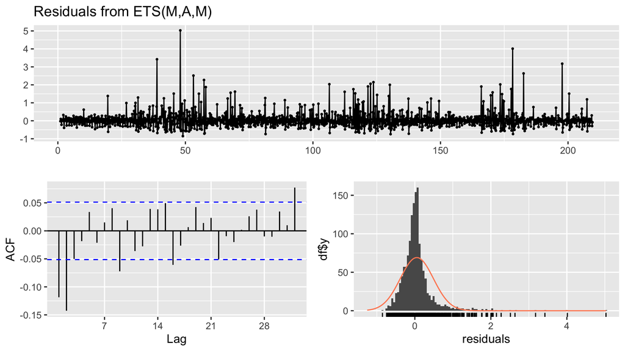

```
##
##  Ljung-Box test
##
## data:  Residuals from ETS(M,A,M)
## Q* = 75.306, df = 14, p-value = 2.08e-10
##
## Model df: 0.   Total lags used: 14
```

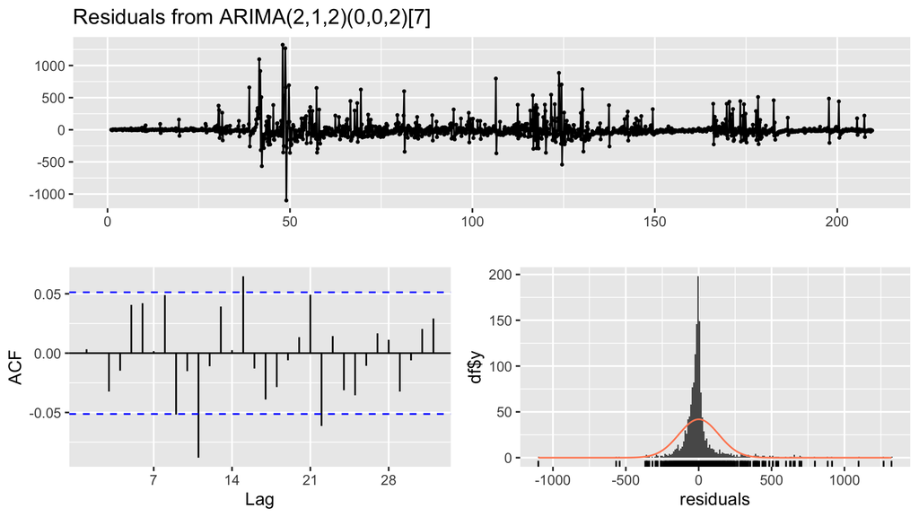

```
##
##  Ljung-Box test
##
## data:  Residuals from ARIMA(2,1,2)(0,0,2)[7]
## Q* = 28.612, df = 8, p-value = 0.0003708
##
## Model df: 6.   Total lags used: 14
```

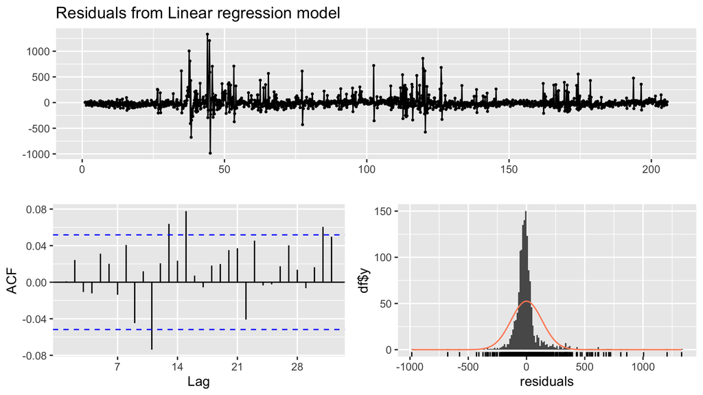

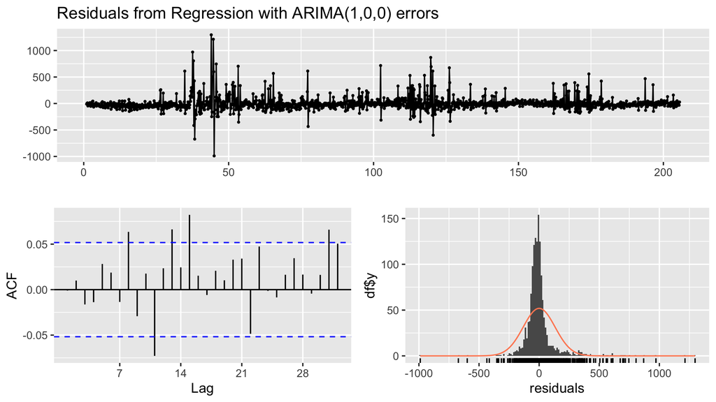

```
##
##  Ljung-Box test
##
## data:  Residuals from Regression with ARIMA(1,0,0) errors
## Q* = 25.899, df = 13, p-value = 0.01754
##
## Model df: 1.   Total lags used: 14
```

```r
train_dat <- initial_data[initial_data$Date >= warmup_date, ]
fill_median <- function(x) {
  for (j in seq_len(ncol(x))) x[is.na(x[, j]), j] <- median(x[, j], na.rm = TRUE)
  x
}

cfg <- selected$ETS$config
fit_ets <- ets(train_ts, model = cfg$model, damped = cfg$damped)
cfg <- selected$SARIMA$config
fit_sarima <- Arima(train_ts, order = cfg$order, seasonal = cfg$seasonal, include.constant = cfg$constant)

y_feat <- ts(train_dat$DailyUSEP, frequency = 7)  # feature models start after the 28-day warm-up
x_tslm <- fill_median(as.matrix(train_dat[feature_names("TSLM", 4L, selected$TSLM$tpc)]))
fit_tslm <- tslm(y_feat ~ x_tslm)

cfg <- selected$DynamicRegression$config
x_dr <- fill_median(as.matrix(train_dat[feature_names("DynamicRegression", 4L, selected$DynamicRegression$tpc)]))
fit_dr <- Arima(y_feat, xreg = x_dr, order = cfg$order, seasonal = cfg$seasonal, include.constant = cfg$constant)

insample_test <- function(fit, model) {
  out <- checkresiduals(fit)  # residual plots + test
  if (!inherits(out, "htest")) return(NULL)
  data.frame(Model = model, Test = out$method, Statistic = unname(out$statistic), p = out$p.value)
}
insample_tests <- bind_rows(insample_test(fit_ets, "ETS"), insample_test(fit_sarima, "SARIMA"),
                            insample_test(fit_tslm, "TSLM"), insample_test(fit_dr, "DynamicRegression"))
```

```r
if (nrow(insample_tests) == 0) insample_tests <- data.frame(Note = "See the printed checkresiduals() output above")
kable(insample_tests, digits = 3, row.names = FALSE, caption = "In-sample residual tests, training period")
```

In-sample residual tests, training period

| Model | Test | Statistic | p |
| --- | --- | --- | --- |
| ETS | Ljung-Box test | 75.306 | 0.000 |
| SARIMA | Ljung-Box test | 28.612 | 0.000 |
| TSLM | Breusch-Godfrey test for serial correlation of order up to 22 | 49.091 | 0.001 |
| DynamicRegression | Ljung-Box test | 25.899 | 0.018 |

**Out-of-sample (all models).** One-step forecast errors (actual − forecast; positive = under-prediction): Ljung-Box at 14 lags for each period, and ADF/KPSS on the 608 pooled 2025–2026 errors to check whether the error mean drifts.

```r
error_diagnostics <- bind_rows(lapply(eval_models, function(m) {
  e_val  <- val$Actual - val[[m]]
  e_test <- test$Actual - test[[m]]
  e_all  <- c(e_val, e_test)
  kp <- kpss.test(e_all)
  data.frame(Model = m,
             LB_val_p  = Box.test(e_val,  lag = 14, type = "Ljung-Box")$p.value,
             LB_test_p = Box.test(e_test, lag = 14, type = "Ljung-Box")$p.value,
             KPSS = unname(kp$statistic), KPSS_p = kp$p.value, ADF_p = adf.test(e_all)$p.value,
             MeanError_2025 = mean(e_val), MeanError_2026 = mean(e_test))
}))
kable(error_diagnostics, digits = 3, row.names = FALSE, caption = "Table 8. Diagnostics of one-step forecast errors")
```

Table 8. Diagnostics of one-step forecast errors

| Model | LB_val_p | LB_test_p | KPSS | KPSS_p | ADF_p | MeanError_2025 | MeanError_2026 |
| --- | --- | --- | --- | --- | --- | --- | --- |
| Naive | 0.000 | 0.000 | 0.016 | 0.10 | 0.01 | -0.032 | 0.770 |
| SeasonalNaive | 0.000 | 0.000 | 0.133 | 0.10 | 0.01 | -0.215 | 8.092 |
| ETS | 0.000 | 0.000 | 0.010 | 0.10 | 0.01 | -1.198 | -0.649 |
| SARIMA | 0.038 | 0.003 | 1.356 | 0.01 | 0.01 | -0.942 | 11.148 |
| TSLM | 0.027 | 0.000 | 1.669 | 0.01 | 0.01 | 3.227 | 25.948 |
| DynamicRegression | 0.002 | 0.000 | 1.025 | 0.01 | 0.01 | -2.740 | 11.175 |
| XGBoost | 0.062 | 0.000 | 0.796 | 0.01 | 0.01 | -4.864 | 4.970 |
| LSTM | 0.115 | 0.000 | 1.179 | 0.01 | 0.01 | -3.159 | 9.332 |

## 5.3 Diebold-Mariano tests

`dm.test()` (with the Harvey-Leybourne-Newbold correction) compares two error series. `power = 2` compares squared errors (the RMSE criterion), `power = 1` absolute errors (the MAE criterion). A negative statistic means the first model has the smaller loss. Validation was used for tuning, so the test period carries the conclusions.

```r
dm <- function(df, a, b, power = 2) {
  d <- dm.test(df$Actual - df[[a]], df$Actual - df[[b]], h = 1, power = power)
  c(DM = unname(d$statistic), p = unname(d$p.value))
}
dm_table <- function(pairs) {
  out <- t(sapply(pairs, function(p) c(val_sq  = dm(val,  p[1], p[2], 2), val_abs  = dm(val,  p[1], p[2], 1),
                                       test_sq = dm(test, p[1], p[2], 2), test_abs = dm(test, p[1], p[2], 1))))
  rownames(out) <- sapply(pairs, paste, collapse = " vs ")
  out
}
as_table <- function(m) data.frame(Comparison = rownames(m), m, row.names = NULL, check.names = FALSE)

# Table 9: every model against yesterday's price
dm9 <- dm_table(lapply(setdiff(eval_models, "Naive"), function(m) c(m, "Naive")))
kable(as_table(dm9), digits = 3, caption = "Table 9. DM tests against the naive benchmark")
```

Table 9. DM tests against the naive benchmark

| Comparison | val_sq.DM | val_sq.p | val_abs.DM | val_abs.p | test_sq.DM | test_sq.p | test_abs.DM | test_abs.p |
| --- | --- | --- | --- | --- | --- | --- | --- | --- |
| SeasonalNaive vs Naive | 1.275 | 0.203 | 2.972 | 0.003 | 0.698 | 0.486 | 2.003 | 0.046 |
| ETS vs Naive | -0.700 | 0.485 | 2.613 | 0.009 | -0.106 | 0.916 | 1.530 | 0.127 |
| SARIMA vs Naive | -1.503 | 0.134 | -1.601 | 0.110 | -2.078 | 0.039 | -2.295 | 0.023 |
| TSLM vs Naive | 0.204 | 0.838 | 5.322 | 0.000 | 0.879 | 0.381 | 4.057 | 0.000 |
| DynamicRegression vs Naive | -0.085 | 0.932 | 6.282 | 0.000 | -0.492 | 0.624 | 2.452 | 0.015 |
| XGBoost vs Naive | -1.753 | 0.081 | -0.162 | 0.872 | -1.659 | 0.098 | -0.240 | 0.810 |
| LSTM vs Naive | -1.421 | 0.156 | 0.898 | 0.370 | -1.470 | 0.143 | -0.634 | 0.527 |

```r
# Table 10: pairwise tests among the three best models by test RMSE
top3 <- head(top4, 3)
dm10 <- dm_table(combn(top3, 2, simplify = FALSE))
kable(as_table(dm10), digits = 3, caption = "Table 10. Pairwise DM tests among the three best models by test RMSE")
```

Table 10. Pairwise DM tests among the three best models by test RMSE

| Comparison | val_sq.DM | val_sq.p | val_abs.DM | val_abs.p | test_sq.DM | test_sq.p | test_abs.DM | test_abs.p |
| --- | --- | --- | --- | --- | --- | --- | --- | --- |
| SARIMA vs LSTM | 0.151 | 0.880 | -3.145 | 0.002 | -0.064 | 0.949 | -1.244 | 0.215 |
| SARIMA vs XGBoost | 0.487 | 0.627 | -2.018 | 0.044 | -1.096 | 0.274 | -2.112 | 0.036 |
| LSTM vs XGBoost | 0.608 | 0.543 | 1.670 | 0.096 | -0.720 | 0.472 | -0.645 | 0.520 |

```r
# Holm adjustment over the 40 p-values of Tables 9 and 10 (rows stacked, then adjusted together)
p_cols <- c("val_sq.p", "val_abs.p", "test_sq.p", "test_abs.p")
p_raw  <- rbind(dm9[, p_cols], dm10[, p_cols])
p_holm <- matrix(p.adjust(p_raw, method = "holm"), nrow = nrow(p_raw), dimnames = dimnames(p_raw))
kable(as_table(p_holm), digits = 3, caption = "Holm-adjusted p-values for Tables 9 and 10")
```

Holm-adjusted p-values for Tables 9 and 10

| Comparison | val_sq.p | val_abs.p | test_sq.p | test_abs.p |
| --- | --- | --- | --- | --- |
| SeasonalNaive vs Naive | 1 | 0.114 | 1 | 1.000 |
| ETS vs Naive | 1 | 0.327 | 1 | 1.000 |
| SARIMA vs Naive | 1 | 1.000 | 1 | 0.746 |
| TSLM vs Naive | 1 | 0.000 | 1 | 0.003 |
| DynamicRegression vs Naive | 1 | 0.000 | 1 | 0.507 |
| XGBoost vs Naive | 1 | 1.000 | 1 | 1.000 |
| LSTM vs Naive | 1 | 1.000 | 1 | 1.000 |
| SARIMA vs LSTM | 1 | 0.066 | 1 | 1.000 |
| SARIMA vs XGBoost | 1 | 1.000 | 1 | 1.000 |
| LSTM vs XGBoost | 1 | 1.000 | 1 | 1.000 |

```r
# Table 11: price-history models against regressions with external variables
dm11 <- dm_table(list(c("SARIMA", "TSLM"), c("SARIMA", "DynamicRegression"), c("ETS", "TSLM"), c("ETS", "DynamicRegression")))
kable(as_table(dm11), digits = 3, caption = "Table 11. DM tests: price history only vs external regressors")
```

Table 11. DM tests: price history only vs external regressors

| Comparison | val_sq.DM | val_sq.p | val_abs.DM | val_abs.p | test_sq.DM | test_sq.p | test_abs.DM | test_abs.p |
| --- | --- | --- | --- | --- | --- | --- | --- | --- |
| SARIMA vs TSLM | -4.147 | 0.000 | -7.822 | 0 | -4.701 | 0.000 | -7.389 | 0.000 |
| SARIMA vs DynamicRegression | -2.993 | 0.003 | -8.917 | 0 | -2.925 | 0.004 | -5.446 | 0.000 |
| ETS vs TSLM | -1.126 | 0.261 | -4.356 | 0 | -1.222 | 0.223 | -3.121 | 0.002 |
| ETS vs DynamicRegression | -0.620 | 0.536 | -5.430 | 0 | 0.470 | 0.638 | -1.147 | 0.252 |

## 5.4 Do external variables help? (M0–M4)

```r
incremental_scores <- bind_rows(lapply(names(incremental), function(key)
  cbind(Model = sub("_M[0-4]$", "", key), Step = incremental[[key]]$step,
        score(incremental_prediction$Actual, incremental_prediction[[key]])))) |>
  group_by(Model) |>
  arrange(Step, .by_group = TRUE) |>
  mutate(MarginalRMSEImprovement = 1 - RMSE / lag(RMSE), CumulativeRMSEImprovement = 1 - RMSE / first(RMSE)) |>
  ungroup()
kable(incremental_scores, digits = 3, caption = "Table 12. Test-period accuracy as external variables are added")
```

Table 12. Test-period accuracy as external variables are added

| Model | Step | N | RMSE | MAE | MASE | sMAPE | MarginalRMSEImprovement | CumulativeRMSEImprovement |
| --- | --- | --- | --- | --- | --- | --- | --- | --- |
| DynamicRegression | 0 | 243 | 50.036 | 27.558 | 0.275 | 12.400 | NA | 0.000 |
| DynamicRegression | 1 | 243 | 49.814 | 27.657 | 0.276 | 12.471 | 0.004 | 0.004 |
| DynamicRegression | 2 | 243 | 55.533 | 33.122 | 0.330 | 15.646 | -0.115 | -0.110 |
| DynamicRegression | 3 | 243 | 55.697 | 33.444 | 0.333 | 15.733 | -0.003 | -0.113 |
| DynamicRegression | 4 | 243 | 56.970 | 37.396 | 0.373 | 19.783 | -0.023 | -0.139 |
| XGBoost | 0 | 243 | 52.177 | 32.132 | 0.320 | 14.863 | NA | 0.000 |
| XGBoost | 1 | 243 | 51.844 | 31.066 | 0.310 | 14.314 | 0.006 | 0.006 |
| XGBoost | 2 | 243 | 53.094 | 31.842 | 0.317 | 14.750 | -0.024 | -0.018 |
| XGBoost | 3 | 243 | 52.039 | 32.104 | 0.320 | 15.014 | 0.020 | 0.003 |
| XGBoost | 4 | 243 | 53.018 | 31.239 | 0.311 | 14.230 | -0.019 | -0.016 |

Why the reserve and regulation prices (step M2) hurt the dynamic regression: the primary-reserve price shifts far above its training range in 2026, and the contingency-reserve and regulation prices are highly correlated.

```r
train_rows <- daily$Sample == "Train"
test_rows  <- daily$Sample == "Test"
data.frame(Sample = c("Train", "Test"),
           Mean     = c(mean(daily$PrimaryReserve[train_rows]), mean(daily$PrimaryReserve[test_rows])),
           Median   = c(median(daily$PrimaryReserve[train_rows]), median(daily$PrimaryReserve[test_rows])),
           Skewness = c(skew(daily$PrimaryReserve[train_rows]), skew(daily$PrimaryReserve[test_rows]))) |>
  kable(digits = 2, caption = "Primary reserve price (SGD/MWh), training vs test")
```

Primary reserve price (SGD/MWh), training vs test

| Sample | Mean | Median | Skewness |
| --- | --- | --- | --- |
| Train | 1.6 | 0.35 | 11.13 |
| Test | 18.7 | 6.98 | 2.70 |

```r
# Correlations in the training period
round(c(Contingency_vs_Regulation = cor(daily$ContingencyReserve[train_rows], daily$Regulation[train_rows]),
        USEP_vs_Contingency_lag1 = cor(initial_data$DailyUSEP, initial_data$ContingencyReserve_lag1, use = "complete.obs"),
        USEP_vs_Regulation_lag1  = cor(initial_data$DailyUSEP, initial_data$Regulation_lag1, use = "complete.obs"),
        USEP_vs_Primary_lag1     = cor(initial_data$DailyUSEP, initial_data$PrimaryReserve_lag1, use = "complete.obs")), 3)
```

```
## Contingency_vs_Regulation  USEP_vs_Contingency_lag1   USEP_vs_Regulation_lag1
##                     0.845                     0.332                     0.404
##      USEP_vs_Primary_lag1
##                     0.002
```

```r
# DM test, test period: does adding the M2 block make each model worse than M1?
rbind(DynamicRegression = c(sq = dm(incremental_prediction, "DynamicRegression_M2", "DynamicRegression_M1", 2),
                            abs = dm(incremental_prediction, "DynamicRegression_M2", "DynamicRegression_M1", 1)),
      XGBoost = c(sq = dm(incremental_prediction, "XGBoost_M2", "XGBoost_M1", 2),
                  abs = dm(incremental_prediction, "XGBoost_M2", "XGBoost_M1", 1))) |>
  round(3)
```

```
##                   sq.DM  sq.p abs.DM abs.p
## DynamicRegression 3.755 0.000  4.802 0.000
## XGBoost           1.395 0.164  1.073 0.284
```

## 5.5 Ancillary-price robustness

Two fixes for the M2 block are tried together: the primary-reserve price enters as log(1 + x) or is dropped, and only one of the two highly correlated contingency-reserve and regulation prices is kept. The four combinations are one more tuning choice: for each model and step M2–M4, the combination and the hyperparameters with the lowest 2025 validation RMSE are frozen and then forecast on 2026, as for M0–M4. *The forecasts are made only when `run_models = TRUE` and saved to `output/ancillary_robustness.rds`; otherwise that file is read back.*

```r
ancillary_specs <- c("log_cont", "log_reg", "drop_cont", "drop_reg")
robust_file <- file.path(output_dir, "ancillary_robustness.rds")
if (run_models) {
  robust_runs <- list()
  for (kind in c("DynamicRegression", "XGBoost")) {
    tpc <- incremental[[paste0(kind, "_M4")]]$tpc  # same TPC choice as the M0-M4 runs
    for (step in 2:4) {
      for (spec in ancillary_specs) {
        message(paste("Ancillary robustness", kind, "M", step, spec))
        candidates <- get_candidates(kind, step, tpc, spec)
        val_rmse <- vapply(candidates, function(cfg) tryCatch({
          p <- rolling_predict(kind, cfg, validation_dates, step, tpc, ancillary = spec)
          sqrt(mean((p - val$Actual)^2))
        }, error = function(e) Inf), numeric(1))
        stopifnot(any(is.finite(val_rmse)))
        config <- candidates[[which.min(val_rmse)]]
        robust_runs[[length(robust_runs) + 1L]] <- list(Model = kind, Step = step, Spec = spec, config = config, Val_RMSE = min(val_rmse),
                                                       test = rolling_predict(kind, config, test_dates, step, tpc, ancillary = spec))
      }
    }
  }
  saveRDS(robust_runs, robust_file)
}
robust_runs <- readRDS(robust_file)

# Validation and test RMSE of every variant; the original rows are the M2-M4 runs above
robust_prediction <- data.frame(Date = test_dates, Actual = test$Actual)
for (r in robust_runs) robust_prediction[[paste0(r$Model, "_M", r$Step, "_", r$Spec)]] <- r$test
original_rows <- bind_rows(lapply(c("DynamicRegression", "XGBoost"), function(kind) bind_rows(lapply(2:4, function(step) {
  key <- paste0(kind, "_M", step)
  data.frame(Model = kind, Step = step, Spec = "original", Val_RMSE = incremental[[key]]$RMSE,
             Test_RMSE = rmse(incremental_prediction, key))
}))))
variant_rows <- bind_rows(lapply(robust_runs, function(r)
  data.frame(Model = r$Model, Step = r$Step, Spec = r$Spec, Val_RMSE = r$Val_RMSE, Test_RMSE = sqrt(mean((r$test - test$Actual)^2)))))
ancillary_table <- bind_rows(original_rows, variant_rows) |>
  group_by(Model, Step) |>
  mutate(Selected = Spec != "original" & Val_RMSE == min(Val_RMSE[Spec != "original"])) |>
  ungroup() |>
  arrange(Model, Step)
kable(ancillary_table, digits = 2,
      caption = "Ancillary-price variants at M2-M4 (Selected = lowest validation RMSE among the four variants)")
```

Ancillary-price variants at M2-M4 (Selected = lowest validation RMSE among the four variants)

| Model | Step | Spec | Val_RMSE | Test_RMSE | Selected |
| --- | --- | --- | --- | --- | --- |
| DynamicRegression | 2 | original | 37.31 | 55.53 | FALSE |
| DynamicRegression | 2 | log_cont | 37.97 | 53.17 | FALSE |
| DynamicRegression | 2 | log_reg | 37.83 | 52.42 | FALSE |
| DynamicRegression | 2 | drop_cont | 36.45 | 49.93 | TRUE |
| DynamicRegression | 2 | drop_reg | 36.60 | 49.63 | FALSE |
| DynamicRegression | 3 | original | 36.70 | 55.70 | FALSE |
| DynamicRegression | 3 | log_cont | 37.56 | 53.32 | FALSE |
| DynamicRegression | 3 | log_reg | 37.37 | 52.59 | FALSE |
| DynamicRegression | 3 | drop_cont | 35.90 | 50.44 | TRUE |
| DynamicRegression | 3 | drop_reg | 35.98 | 50.21 | FALSE |
| DynamicRegression | 4 | original | 41.62 | 56.97 | FALSE |
| DynamicRegression | 4 | log_cont | 41.86 | 54.16 | FALSE |
| DynamicRegression | 4 | log_reg | 41.82 | 53.68 | TRUE |
| DynamicRegression | 4 | drop_cont | 42.13 | 51.18 | FALSE |
| DynamicRegression | 4 | drop_reg | 42.05 | 51.05 | FALSE |
| XGBoost | 2 | original | 36.86 | 53.09 | FALSE |
| XGBoost | 2 | log_cont | 36.26 | 51.47 | FALSE |
| XGBoost | 2 | log_reg | 36.36 | 51.54 | FALSE |
| XGBoost | 2 | drop_cont | 36.19 | 50.99 | TRUE |
| XGBoost | 2 | drop_reg | 36.42 | 50.27 | FALSE |
| XGBoost | 3 | original | 35.46 | 52.04 | FALSE |
| XGBoost | 3 | log_cont | 35.70 | 52.91 | FALSE |
| XGBoost | 3 | log_reg | 35.79 | 54.33 | FALSE |
| XGBoost | 3 | drop_cont | 35.62 | 52.38 | TRUE |
| XGBoost | 3 | drop_reg | 36.24 | 52.15 | FALSE |
| XGBoost | 4 | original | 35.23 | 53.02 | FALSE |
| XGBoost | 4 | log_cont | 35.96 | 53.35 | FALSE |
| XGBoost | 4 | log_reg | 36.01 | 51.85 | FALSE |
| XGBoost | 4 | drop_cont | 36.07 | 53.51 | FALSE |
| XGBoost | 4 | drop_reg | 35.93 | 52.44 | TRUE |

```r
# Selected variant against the original specification, test period (negative DM: the variant has the smaller loss)
selected_variants <- filter(ancillary_table, Selected)
ancillary_dm <- bind_rows(lapply(seq_len(nrow(selected_variants)), function(i) {
  s <- selected_variants[i, ]
  original <- paste0(s$Model, "_M", s$Step)
  df <- data.frame(Actual = test$Actual, Variant = robust_prediction[[paste0(original, "_", s$Spec)]],
                   Original = incremental_prediction[[original]])
  sq  <- dm(df, "Variant", "Original", 2)
  ab  <- dm(df, "Variant", "Original", 1)
  data.frame(Model = s$Model, Step = s$Step, Spec = s$Spec, Val_RMSE_original = incremental[[original]]$RMSE,
             Val_RMSE_variant = s$Val_RMSE, Test_RMSE_original = rmse(df, "Original"),
             Test_RMSE_variant = rmse(df, "Variant"), Improvement = 1 - rmse(df, "Variant") / rmse(df, "Original"),
             DM_sq = sq[["DM"]], p_sq = sq[["p"]], DM_abs = ab[["DM"]], p_abs = ab[["p"]])
}))
# Holm correction over the six comparisons, separately for each loss
ancillary_dm$p_sq_holm  <- p.adjust(ancillary_dm$p_sq, "holm")
ancillary_dm$p_abs_holm <- p.adjust(ancillary_dm$p_abs, "holm")
kable(ancillary_dm, digits = 3, caption = "Selected ancillary variant vs the original specification, test period")
```

Selected ancillary variant vs the original specification, test period

| Model | Step | Spec | Val_RMSE_original | Val_RMSE_variant | Test_RMSE_original | Test_RMSE_variant | Improvement | DM_sq | p_sq | DM_abs | p_abs | p_sq_holm | p_abs_holm |
| --- | --- | --- | --- | --- | --- | --- | --- | --- | --- | --- | --- | --- | --- |
| DynamicRegression | 2 | drop_cont | 37.305 | 36.450 | 55.533 | 49.929 | 0.101 | -3.772 | 0.000 | -4.756 | 0.000 | 0.001 | 0.000 |
| DynamicRegression | 3 | drop_cont | 36.701 | 35.895 | 55.697 | 50.442 | 0.094 | -3.888 | 0.000 | -3.906 | 0.000 | 0.001 | 0.001 |
| DynamicRegression | 4 | log_reg | 41.617 | 41.824 | 56.970 | 53.680 | 0.058 | -2.417 | 0.016 | -2.517 | 0.012 | 0.066 | 0.050 |
| XGBoost | 2 | drop_cont | 36.858 | 36.193 | 53.094 | 50.985 | 0.040 | -1.898 | 0.059 | -1.802 | 0.073 | 0.177 | 0.218 |
| XGBoost | 3 | drop_cont | 35.456 | 35.617 | 52.039 | 52.379 | -0.007 | 0.289 | 0.773 | -0.198 | 0.843 | 1.000 | 1.000 |
| XGBoost | 4 | drop_reg | 35.233 | 35.927 | 53.018 | 52.441 | 0.011 | -0.157 | 0.875 | -0.183 | 0.855 | 1.000 | 1.000 |

## 5.6 Prediction intervals

Empirical intervals around each point forecast: the radius is the finite-sample quantile, rank ⌈(n + 1)(1 − α)⌉, of the latest (at most 180, at least 100) realised absolute errors. They start from the 2025 validation errors, and each test error is added only after its day is realised.

```r
interval_models <- c("SeasonalNaive", names(selected))
interval_rows <- list()
for (kind in interval_models) {
  past_errors <- abs(val[[kind]] - val$Actual)
  for (i in seq_len(nrow(test))) {
    calibration <- tail(past_errors, 180L)
    stopifnot(length(calibration) >= 100L)
    for (alpha in c(0.20, 0.05)) {
      rank   <- min(length(calibration), ceiling((length(calibration) + 1L) * (1 - alpha)))
      radius <- sort(calibration)[rank]
      interval_rows[[length(interval_rows) + 1L]] <- data.frame(
        Date = test$Date[i], Model = kind, Level = 1 - alpha, Actual = test$Actual[i], Prediction = test[[kind]][i],
        Lower = test[[kind]][i] - radius, Upper = test[[kind]][i] + radius)
    }
    past_errors <- c(past_errors, abs(test[[kind]][i] - test$Actual[i]))  # today's error becomes usable tomorrow
  }
}
intervals <- bind_rows(interval_rows)
intervals$Covered <- intervals$Actual >= intervals$Lower & intervals$Actual <= intervals$Upper
intervals$Width   <- intervals$Upper - intervals$Lower
# Interval score: width + penalty 2/alpha times the distance by which the actual falls outside
intervals$IntervalScore <- intervals$Width +
  2 / (1 - intervals$Level) * pmax(intervals$Lower - intervals$Actual, 0) +
  2 / (1 - intervals$Level) * pmax(intervals$Actual - intervals$Upper, 0)
interval_summary <- intervals |>
  group_by(Model, Level) |>
  summarise(N = n(), Coverage = mean(Covered), MeanWidth = mean(Width), MeanIntervalScore = mean(IntervalScore), .groups = "drop")
kable(interval_summary, digits = 3, caption = "Table 13. Empirical prediction intervals, test period")
```

Table 13. Empirical prediction intervals, test period

| Model | Level | N | Coverage | MeanWidth | MeanIntervalScore |
| --- | --- | --- | --- | --- | --- |
| DynamicRegression | 0.80 | 243 | 0.700 | 81.965 | 200.194 |
| DynamicRegression | 0.95 | 243 | 0.885 | 143.771 | 353.850 |
| ETS | 0.80 | 243 | 0.667 | 67.231 | 206.830 |
| ETS | 0.95 | 243 | 0.872 | 135.635 | 387.009 |
| LSTM | 0.80 | 243 | 0.687 | 59.334 | 176.081 |
| LSTM | 0.95 | 243 | 0.856 | 112.383 | 327.596 |
| SARIMA | 0.80 | 243 | 0.658 | 48.031 | 171.365 |
| SARIMA | 0.95 | 243 | 0.881 | 108.633 | 333.074 |
| SeasonalNaive | 0.80 | 243 | 0.687 | 72.974 | 230.737 |
| SeasonalNaive | 0.95 | 243 | 0.885 | 166.156 | 428.176 |
| TSLM | 0.80 | 243 | 0.679 | 89.543 | 231.444 |
| TSLM | 0.95 | 243 | 0.877 | 164.970 | 381.182 |
| XGBoost | 0.80 | 243 | 0.667 | 57.961 | 178.895 |
| XGBoost | 0.95 | 243 | 0.881 | 115.601 | 349.797 |

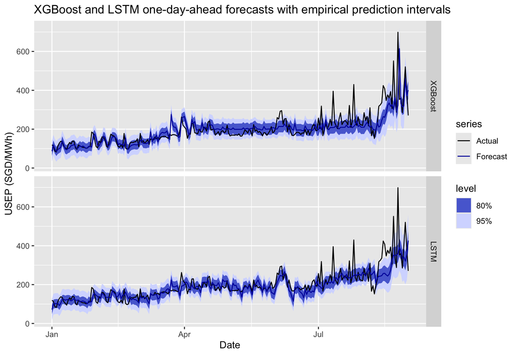

```r
p5 <- intervals |>
  filter(Model %in% c("XGBoost", "LSTM")) |>
  select(Date, Model, Level, Actual, Prediction, Lower, Upper) |>
  pivot_wider(names_from = Level, values_from = c(Lower, Upper)) |>
  mutate(Model = factor(Model, levels = c("XGBoost", "LSTM"))) |>
  ggplot(aes(x = Date)) +
  geom_ribbon(aes(ymin = Lower_0.95, ymax = Upper_0.95, fill = "95%")) +
  geom_ribbon(aes(ymin = Lower_0.8, ymax = Upper_0.8, fill = "80%")) +
  geom_line(aes(y = Actual, colour = "Actual")) +
  geom_line(aes(y = Prediction, colour = "Forecast")) +
  facet_grid(vars(Model)) +
  scale_fill_manual(values = c("80%" = "#596DD5", "95%" = "#D5DBFF")) +
  scale_colour_manual(values = c(Actual = "black", Forecast = "#0000AA")) +
  labs(title = "XGBoost and LSTM one-day-ahead forecasts with empirical prediction intervals",
       y = "USEP (SGD/MWh)", fill = "level", colour = "series")
save_fig(p5, "fig5_intervals.png", 8, 5.5)
```

## 5.7 TPC variable and spike days

```r
kable(tpc_log, digits = 4, caption = "Table 14. TPC retention rule on the 2025 validation period")
```

Table 14. TPC retention rule on the 2025 validation period

| Model | RelativeImprovement | BetterQuarters | KeepTPC |
| --- | --- | --- | --- |
| TSLM | 0.0039 | 3 | FALSE |
| DynamicRegression | 0.0182 | 4 | TRUE |
| XGBoost | -0.0109 | 1 | FALSE |
| LSTM | -0.0035 | 1 | FALSE |

```r
# Normal days vs spike days (actual above the training 95th percentile)
spike <- test$Actual > spike_threshold
day_groups <- list(Normal = !spike, Spike = spike)
spike_table <- bind_rows(lapply(eval_models, function(m) bind_rows(lapply(names(day_groups), function(g) {
  keep <- day_groups[[g]]
  if (!any(keep)) return(NULL)
  cbind(Model = m, Group = g, score(test$Actual[keep], test[[m]][keep]),
        Underprediction = mean(test[[m]][keep] < test$Actual[keep]),
        MeanShortfall   = mean(pmax(test$Actual[keep] - test[[m]][keep], 0)))
}))))
kable(spike_table, digits = 2, row.names = FALSE, caption = "Table C1. Test-period accuracy on normal and spike days")
```

Table C1. Test-period accuracy on normal and spike days

| Model | Group | N | RMSE | MAE | MASE | sMAPE | Underprediction | MeanShortfall |
| --- | --- | --- | --- | --- | --- | --- | --- | --- |
| Naive | Normal | 242 | 53.11 | 30.20 | 0.30 | 13.54 | 0.49 | 14.64 |
| Naive | Spike | 1 | 410.90 | 410.90 | 4.10 | 83.32 | 1.00 | 410.90 |
| SeasonalNaive | Normal | 242 | 61.85 | 37.12 | 0.37 | 17.08 | 0.60 | 21.96 |
| SeasonalNaive | Spike | 1 | 322.28 | 322.28 | 3.21 | 59.96 | 1.00 | 322.28 |
| ETS | Normal | 242 | 55.27 | 33.72 | 0.34 | 14.94 | 0.51 | 15.89 |
| ETS | Spike | 1 | 313.89 | 313.89 | 3.13 | 57.95 | 1.00 | 313.89 |
| SARIMA | Normal | 242 | 43.24 | 26.65 | 0.27 | 12.52 | 0.62 | 18.10 |
| SARIMA | Spike | 1 | 400.27 | 400.27 | 3.99 | 80.30 | 1.00 | 400.27 |
| TSLM | Normal | 242 | 59.43 | 40.89 | 0.41 | 23.75 | 0.64 | 32.75 |
| TSLM | Spike | 1 | 347.53 | 347.53 | 3.47 | 66.21 | 1.00 | 347.53 |
| DynamicRegression | Normal | 242 | 52.46 | 36.10 | 0.36 | 19.59 | 0.50 | 22.94 |
| DynamicRegression | Spike | 1 | 350.39 | 350.39 | 3.49 | 66.94 | 1.00 | 350.39 |
| XGBoost | Normal | 242 | 47.30 | 29.81 | 0.30 | 13.98 | 0.45 | 16.62 |
| XGBoost | Spike | 1 | 376.31 | 376.31 | 3.75 | 73.72 | 1.00 | 376.31 |
| LSTM | Normal | 242 | 45.55 | 28.81 | 0.29 | 13.95 | 0.53 | 18.39 |
| LSTM | Spike | 1 | 339.29 | 339.29 | 3.38 | 64.14 | 1.00 | 339.29 |

## 5.8 Recommendation

```r
validation_rmse <- sapply(names(selected), function(m) rmse(val, m))
eligible <- names(validation_rmse)[validation_rmse <= min(validation_rmse) * 1.01]
simplicity <- c("ETS", "SARIMA", "TSLM", "DynamicRegression", "XGBoost", "LSTM")
round(sort(validation_rmse), 2)
```

```
##           XGBoost              LSTM            SARIMA               ETS
##             35.23             35.92             36.16             40.44
## DynamicRegression              TSLM
##             41.62             42.63
```

```r
c(Recommended = recommended, RuleCheck = simplicity[simplicity %in% eligible][1])
```

```
## Recommended   RuleCheck
##   "XGBoost"   "XGBoost"
```

## 5.9 Why the validation and test rankings differ

```r
# Price level and volatility in the two evaluation periods
regime <- data.frame(Sample = c("Validation 2025", "Test 2026"), N = c(nrow(val), nrow(test)),
                     Mean = c(mean(val$Actual), mean(test$Actual)), SD = c(sd(val$Actual), sd(test$Actual)))
kable(regime, digits = 1, caption = "Daily USEP in the validation and test periods (SGD/MWh)")
```

Daily USEP in the validation and test periods (SGD/MWh)

| Sample | N | Mean | SD |
| --- | --- | --- | --- |
| Validation 2025 | 365 | 116.6 | 42.4 |
| Test 2026 | 243 | 197.1 | 81.2 |

```r
# Mean error (actual - forecast; positive = under-prediction); high-price days = top 10% of test actuals
high <- test$Actual > quantile(test$Actual, 0.9)
bias_table <- bind_rows(lapply(top3, function(m)
  data.frame(Model = m, MeanError_val = mean(val$Actual - val[[m]]), MeanError_test = mean(test$Actual - test[[m]]),
             MeanError_test_high = mean((test$Actual - test[[m]])[high]))))
kable(bias_table, digits = 2, caption = "Mean forecast error of the three best models by test RMSE")
```

Mean forecast error of the three best models by test RMSE

| Model | MeanError_val | MeanError_test | MeanError_test_high |
| --- | --- | --- | --- |
| SARIMA | -0.94 | 11.15 | 79.87 |
| LSTM | -3.16 | 9.33 | 100.26 |
| XGBoost | -4.86 | 4.97 | 89.48 |

```r
# How concentrated is the test-best model's advantage over the recommended model?
test_best <- top4[1]
d <- (test$Actual - test[[recommended]])^2 - (test$Actual - test[[test_best]])^2  # > 0: test-best model better that day
top10 <- order(abs(d), decreasing = TRUE)[1:10]
concentration <- data.frame(Comparison = paste(test_best, "vs", recommended),
                            ShareFromTop10Days = sum(d[top10]) / sum(d),
                            RMSE_TestBest_excl_top10 = sqrt(mean((test$Actual - test[[test_best]])[-top10]^2)),
                            RMSE_Recommended_excl_top10 = sqrt(mean((test$Actual - test[[recommended]])[-top10]^2)),
                            TestDaysNeededFor5pctDM = (qnorm(0.975) * sd(d) / mean(d))^2)
kable(concentration, digits = 2, caption = "Concentration of the test-best model's advantage")
```

Concentration of the test-best model’s advantage

| Comparison | ShareFromTop10Days | RMSE_TestBest_excl_top10 | RMSE_Recommended_excl_top10 | TestDaysNeededFor5pctDM |
| --- | --- | --- | --- | --- |
| SARIMA vs XGBoost | 0.36 | 37.64 | 40.13 | 777.42 |

# 6 Next-day forecast: 1 September 2026

Forecasts for the first day after the data end, made with the frozen settings. The realised value (mean of the 48 periods in `USEP.xlsx`) is shown only for comparison.

```r
next_day <- next_prediction
next_day$Actual <- usep$DailyUSEP[usep$Date == end_date + 1L]
next_day$Error  <- next_day$Actual - next_day$Prediction
next_day <- next_day[order(-next_day$Prediction), ]
kable(next_day, digits = 2, row.names = FALSE, caption = "Table 15. One-day-ahead forecasts for 2026-09-01 (SGD/MWh)")
```

Table 15. One-day-ahead forecasts for 2026-09-01 (SGD/MWh)

| Date | Model | Prediction | Actual | Error |
| --- | --- | --- | --- | --- |
| 2026-09-01 | LSTM | 374.85 | 265.72 | -109.13 |
| 2026-09-01 | SeasonalNaive | 352.84 | 265.72 | -87.11 |
| 2026-09-01 | XGBoost | 334.13 | 265.72 | -68.41 |
| 2026-09-01 | ETS | 329.82 | 265.72 | -64.09 |
| 2026-09-01 | SARIMA | 292.49 | 265.72 | -26.77 |
| 2026-09-01 | DynamicRegression | 289.99 | 265.72 | -24.27 |
| 2026-09-01 | TSLM | 286.81 | 265.72 | -21.08 |

# 7 Export

```r
# Feature tables actually used for each test week (one preprocessing cut-off per re-estimation)
collect_test_features <- function(i) {
  cutoff <- test_dates[i] - 1L
  dat <- prepare_features(cutoff, min(end_date, cutoff + refit_days))
  dat <- dat[dat$Date > cutoff, ]
  dat$PreprocessingCutoff <- cutoff
  dat
}
processed_test <- bind_rows(lapply(seq(1L, length(test_dates), by = refit_days), collect_test_features))

write_xlsx(list(Daily = usep_sample, Train_Features = initial_data, Test_Features = processed_test,
                Temperature_CV = temperature_cv, Holiday_Dates = data.frame(Date = holiday_dates)),
           file.path(output_dir, "processed_data.xlsx"))

write_xlsx(list(Descriptive = annual, Stationarity = stationarity, Frozen_Settings = frozen_table,
                Accuracy = accuracy_table, Residuals_InSample = insample_tests, Residuals_Errors = error_diagnostics,
                DM_vs_Naive = as_table(dm9), DM_Top3 = as_table(dm10), DM_Holm = as_table(p_holm),
                Regime = regime, Bias_Top3 = bias_table, Concentration = concentration,
                DM_External = as_table(dm11), Incremental = incremental_scores,
                Ancillary_Variants = ancillary_table, Ancillary_DM = ancillary_dm, Intervals = interval_summary,
                TPC = tpc_log, Spike_Normal = spike_table, NextDay = next_day, Intervals_Daily = intervals),
           file.path(output_dir, "report_tables.xlsx"))
```

# 8 Appendix: temperature reconstruction

```r
longest_gap <- function(x) {
  r <- rle(is.na(x))
  max(c(0L, r$lengths[r$values]))
}
temp_gaps <- data.frame(Station     = stations,
                        MissingDays = colSums(is.na(usep_sample[stations])),
                        LongestGap  = vapply(usep_sample[stations], longest_gap, numeric(1)),
                        Lambda      = c(NA, temperature_lambda[stations[-1]]))
kable(temp_gaps, row.names = FALSE, caption = "Missing station-days, 2021-01-01 to 2026-08-31")
```

Missing station-days, 2021-01-01 to 2026-08-31

| Station | MissingDays | LongestGap | Lambda |
| --- | --- | --- | --- |
| Changi | 0 | 0 | NA |
| Jurong_West | 30 | 5 | 0.1 |
| Ang_Mo_Kio | 31 | 9 | 0.1 |
| Admiralty | 76 | 36 | 10.0 |
| Sentosa_Island | 50 | 10 | 10.0 |

```r
c(DaysWithoutRawFiveStationMean = sum(is.na(usep_sample$TempSG_raw)))
```

```
## DaysWithoutRawFiveStationMean
##                           174
```

```r
# Reconstruction error at the chosen lambda (N counts masked evaluations, not distinct days)
kable(temperature_cv[temperature_cv$Lambda == temperature_lambda[temperature_cv$Station], ], digits = 3,
      row.names = FALSE, caption = "Table B1. Station reconstruction error at the chosen lambda")
```

Table B1. Station reconstruction error at the chosen lambda

| Station | Lambda | N | MAE | RMSE |
| --- | --- | --- | --- | --- |
| Jurong_West | 0.1 | 126 | 0.355 | 0.461 |
| Ang_Mo_Kio | 0.1 | 129 | 0.151 | 0.205 |
| Admiralty | 10.0 | 129 | 0.155 | 0.197 |
| Sentosa_Island | 10.0 | 113 | 0.381 | 0.485 |